# Prem_Vishnoi

### Test Items starts from here - There are 5 sections - 75 points total

##### Section 1: (15 points)

##### (1) R has probability functions available for use (Kabacoff, Section 5.2.3). Using one distribution to approximate another is not uncommon.

(1)(a) (6 points) The Poisson distribution may be used to approximate the binomial distribution if n > 20 and np < 7. Estimate the following binomial probabilities using *dpois()* or *ppois()* with probability p = 0.05, and n = 100. Then, estimate the same probabilities using *dbinom()* or *pbinom()*. Show the numerical results of your calculations.

1. The probability of exactly 0 successes.

```r
# Parameters
n <- 100
p <- 0.05
lambda <- n * p  # lambda = 5 for Poisson approximation

# Poisson approximation
poisson_prob <- dpois(0, lambda)

# Exact binomial probability
binomial_prob <- dbinom(0, size = n, prob = p)

# Display results
cat("Poisson approximation: P(X = 0) =", round(poisson_prob, 6), "\n")
```

```
## Poisson approximation: P(X = 0) = 0.006738
```

```r
cat("Binomial exact: P(X = 0) =", round(binomial_prob, 6), "\n")
```

```
## Binomial exact: P(X = 0) = 0.005921
```

2. The probability of fewer than 6 successes. Please note the following, taken from the Binomial Distribution R Documentation page, regarding the “lower.tail” argument:

lower.tail logical; if TRUE (default), probabilities are P[X ≤ x], otherwise, P[X > x].

```r
# Probability of fewer than 6 successes means P(X <= 5)
# Poisson approximation
poisson_prob <- ppois(5, lambda, lower.tail = TRUE)

# Exact binomial probability
binomial_prob <- pbinom(5, size = n, prob = p, lower.tail = TRUE)

# Display results
cat("Poisson approximation: P(X < 6) =", round(poisson_prob, 6), "\n")
```

```
## Poisson approximation: P(X < 6) = 0.615961
```

```r
cat("Binomial exact: P(X < 6) =", round(binomial_prob, 6), "\n")
```

```
## Binomial exact: P(X < 6) = 0.615999
```

The binomial may also be approximated via the normal distribution. Estimate the following binomial probabilities using *dnorm()* or *pnorm()*, this time with probability p = 0.25 and n = 100. Then, calculate the same probabilities using *dbinom()* and *pbinom()*. Use continuity correction. Show the numerical results of your calculations.

3. The probability of exactly 25 successes.

```r
# Parameters for normal approximation
n <- 100
p <- 0.25
mu <- n * p  # mean = 25
sigma <- sqrt(n * p * (1 - p))  # standard deviation

# Normal approximation with continuity correction
# P(X = 25) ≈ P(24.5 < X < 25.5)
normal_prob <- pnorm(25.5, mean = mu, sd = sigma) - pnorm(24.5, mean = mu, sd = sigma)

# Exact binomial probability
binomial_prob <- dbinom(25, size = n, prob = p)

# Display results
cat("Normal approximation: P(X = 25) =", round(normal_prob, 6), "\n")
```

```
## Normal approximation: P(X = 25) = 0.091927
```

```r
cat("Binomial exact: P(X = 25) =", round(binomial_prob, 6), "\n")
```

```
## Binomial exact: P(X = 25) = 0.0918
```

4. The probability of fewer than 20 successes. Please note the following, taken from the Normal Distribution R Documentation page, regarding the “lower.tail” argument:

lower.tail logical; if TRUE (default), probabilities are P[X ≤ x], otherwise, P[X > x].

```r
# P(X < 20) means P(X <= 19)
# With continuity correction: P(X <= 19.5)
normal_prob <- pnorm(19.5, mean = mu, sd = sigma, lower.tail = TRUE)

# Exact binomial probability
binomial_prob <- pbinom(19, size = n, prob = p, lower.tail = TRUE)

# Display results
cat("Normal approximation: P(X < 20) =", round(normal_prob, 6), "\n")
```

```
## Normal approximation: P(X < 20) = 0.102012
```

```r
cat("Binomial exact: P(X < 20) =", round(binomial_prob, 6), "\n")
```

```
## Binomial exact: P(X < 20) = 0.09953
```

(1)(b) (3 points) Generate side-by-side barplots using *par(mfrow = c(1,2))* or *grid.arrange()*. The left barplot will show Poisson probabilties for outcomes ranging from 0 to 10. The right barplot will show binomial probabilities for outcomes ranging from 0 to 10. Use p = 0.05 and n = 100. Title each plot, present in color and assign names to the bar; i.e. x-axis value labels.

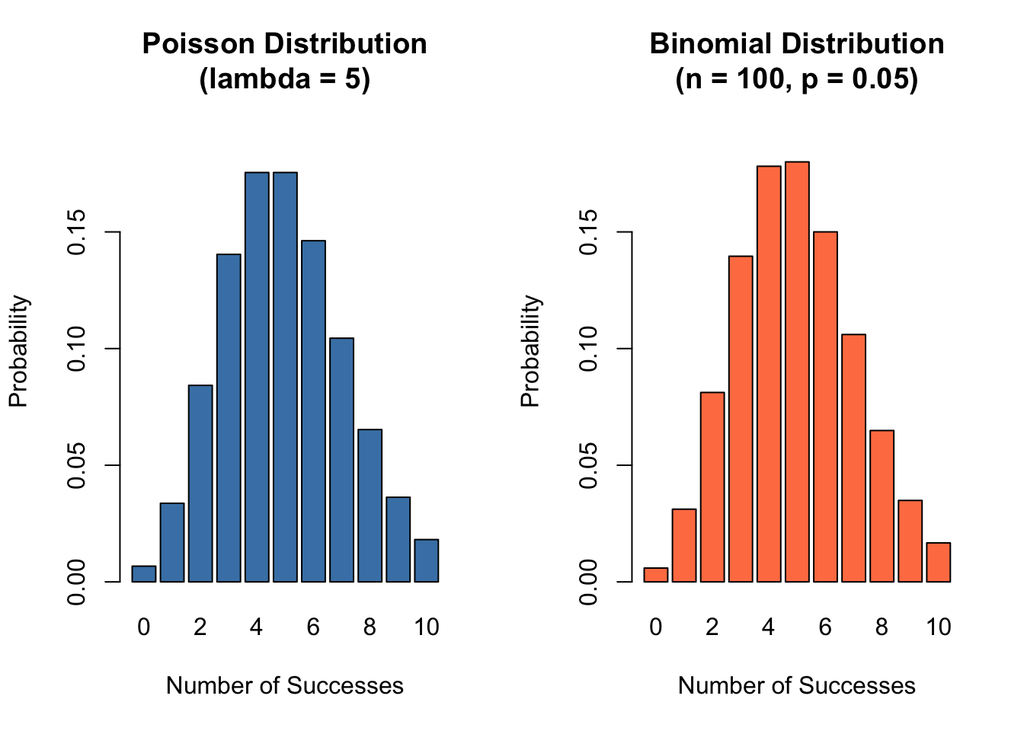

```r
# Parameters
n <- 100
p <- 0.05
lambda <- n * p
outcomes <- 0:10

# Calculate probabilities
poisson_probs <- dpois(outcomes, lambda)
binomial_probs <- dbinom(outcomes, size = n, prob = p)

# Create side-by-side barplots
par(mfrow = c(1, 2))

barplot(poisson_probs, names.arg = outcomes, col = "steelblue",
        main = "Poisson Distribution\n(lambda = 5)",
        xlab = "Number of Successes", ylab = "Probability",
        ylim = c(0, max(c(poisson_probs, binomial_probs)) * 1.1))

barplot(binomial_probs, names.arg = outcomes, col = "coral",
        main = "Binomial Distribution\n(n = 100, p = 0.05)",
        xlab = "Number of Successes", ylab = "Probability",
        ylim = c(0, max(c(poisson_probs, binomial_probs)) * 1.1))
```

```r
par(mfrow = c(1, 1))  # Reset plot layout
```

```r
# Define outcomes and probabilities
outcomes <- 0:6
probs <- c(0.214, 0.230, 0.240, 0.182, 0.130, 0.003, 0.001)

# Calculate expected value (mean)
expected_value <- sum(outcomes * probs)

# Calculate variance
variance <- sum((outcomes - expected_value)^2 * probs)

# Display results
cat("Expected Value (Mean):", round(expected_value, 2), "\n")
```

```
## Expected Value (Mean): 1.8
```

```r
cat("Variance:", round(variance, 2), "\n")
```

```
## Variance: 1.79
```

2. Use the *cumsum()* function and plot the cumulative probabilties versus the corresponding outcomes. Detemine the value of the median for this distribution and show on this plot. Note that there are methods for interpolating a median. However, we can identify an appropriate median from our set of our outcomes - 0 through 6 - that satisfies the definition. Creating a stair-step plot of the cumulative probability as a function of the outcomes may be helpful in identifying it.

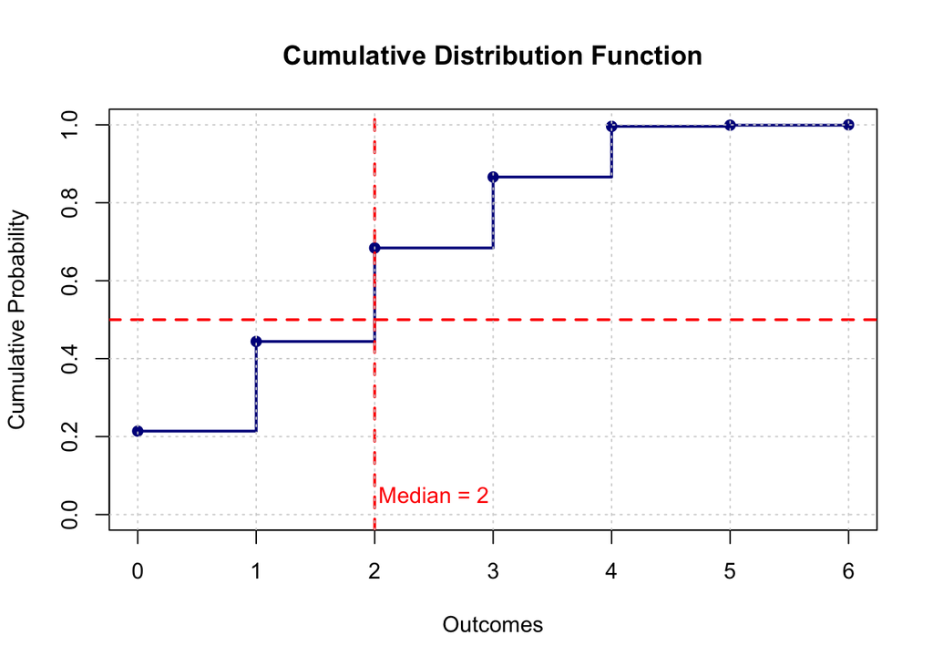

```r
# Calculate cumulative probabilities
cum_probs <- cumsum(probs)

# Find median: smallest value where cumulative probability >= 0.5
median_value <- outcomes[which(cum_probs >= 0.5)[1]]

# Create stair-step plot
plot(outcomes, cum_probs, type = "s", lwd = 2, col = "darkblue",
     main = "Cumulative Distribution Function",
     xlab = "Outcomes", ylab = "Cumulative Probability",
     ylim = c(0, 1))
points(outcomes, cum_probs, pch = 19, col = "darkblue")
abline(h = 0.5, col = "red", lty = 2, lwd = 2)
abline(v = median_value, col = "red", lty = 2, lwd = 2)
text(median_value + 0.5, 0.05, paste("Median =", median_value), col = "red")
grid()
```

##### Section 2: (15 points)

##### (2) Conditional probabilities appear in many contexts and, in particular, are used by Bayes’ Theorem. Correlations are another means for evaluating dependency between variables. The dataset “faithful”” is part of the “datasets” package and may be loaded with the statement *data(faithful)*. It contains 272 observations of 2 variables; waiting time between eruptions (in minutes) and the duration of the eruption (in minutes) for the Old Faithful geyser in Yellowstone National Park.

(2)(a) (6 points) Load the “faithful” dataset and present summary statistics and a histogram of waiting times. Additionally, compute the empirical conditional probability of an eruption less than 3.0 minutes, if the waiting time exceeds 70 minutes.

```r
data(faithful, package = "datasets")

# Summary statistics
cat("Summary Statistics for Waiting Times:\n")
```

```
## Summary Statistics for Waiting Times:
```

```r
print(summary(faithful$waiting))
```

```
##    Min. 1st Qu.  Median    Mean 3rd Qu.    Max.
##    43.0    58.0    76.0    70.9    82.0    96.0
```

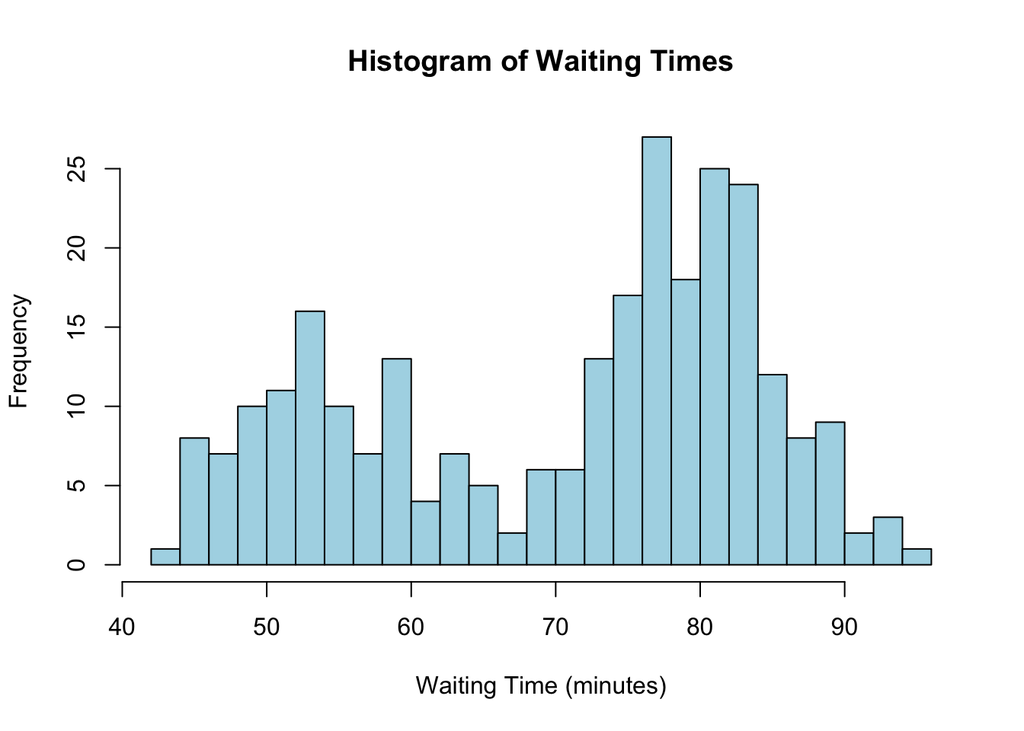

```r
# Histogram of waiting times
hist(faithful$waiting, col = "lightblue", main = "Histogram of Waiting Times",
     xlab = "Waiting Time (minutes)", ylab = "Frequency", breaks = 20)
```

```r
# Conditional probability: P(eruptions < 3.0 | waiting > 70)
condition_waiting <- faithful$waiting > 70
condition_eruption <- faithful$eruptions < 3.0

# Count observations meeting the waiting condition
n_waiting_70 <- sum(condition_waiting)

# Count observations meeting both conditions
n_both <- sum(condition_waiting & condition_eruption)

# Calculate conditional probability
conditional_prob <- n_both / n_waiting_70

cat("\nConditional Probability:\n")
```

```
##
## Conditional Probability:
```

```r
cat("P(eruptions < 3.0 | waiting > 70) =", round(conditional_prob, 4), "\n")
```

```
## P(eruptions < 3.0 | waiting > 70) = 0.0061
```

1. Identify any observations in “faithful” for which the waiting time exceeds 70 minutes and the eruptions are less than 3.0 minutes. List and show any such observations in a distinct color on a scatterplot of all eruption (vertical axis) and waiting times (horizontal axis). Include a horizontal line at eruption = 3.0, and a vertical line at waiting time = 70. Add a title and appropriate text.

```r
# Identify observations meeting both conditions
special_obs <- faithful[condition_waiting & condition_eruption, ]

# Display these observations
cat("Observations with waiting > 70 AND eruptions < 3.0:\n")
```

```
## Observations with waiting > 70 AND eruptions < 3.0:
```

```r
print(special_obs)
```

```
##     eruptions waiting
## 211     2.383      71
```

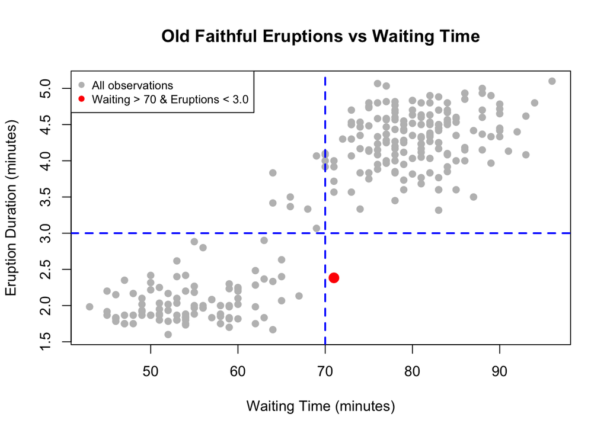

```r
# Create scatterplot
plot(faithful$waiting, faithful$eruptions,
     pch = 19, col = "gray",
     main = "Old Faithful Eruptions vs Waiting Time",
     xlab = "Waiting Time (minutes)",
     ylab = "Eruption Duration (minutes)")

# Highlight special observations
points(special_obs$waiting, special_obs$eruptions,
       pch = 19, col = "red", cex = 1.5)

# Add reference lines
abline(h = 3.0, col = "blue", lwd = 2, lty = 2)
abline(v = 70, col = "blue", lwd = 2, lty = 2)

# Add legend
legend("topleft", legend = c("All observations", "Waiting > 70 & Eruptions < 3.0"),
       col = c("gray", "red"), pch = 19, cex = 0.8)
```

2. What does the plot suggest about the relationship between eruption time and waiting time?

*Answer: The plot suggests a strong positive relationship between eruption duration and waiting time. There appear to be two distinct clusters of data, indicating a bimodal distribution. Longer eruptions are associated with longer waiting times until the next eruption, and shorter eruptions are associated with shorter waiting times. The observations meeting our condition (waiting > 70 and eruptions < 3.0) are rare, appearing in the transition zone between these two clusters.*

(2)(b) (6 points) Past research indicates that the waiting times between consecutive eruptions are not independent. This problem will check to see if there is evidence of this. Form consecutive pairs of waiting times. In other words, pair the first and second waiting times, pair the third and fourth waiting times, and so forth. There are 136 resulting consecutive pairs of waiting times. Form a data frame with the first column containing the first waiting time in a pair and the second column with the second waiting time in a pair. Plot the pairs with the second member of a pair on the vertical axis and the first member on the horizontal axis.

One way to do this is to pass the vector of waiting times - faithful$waiting - to *matrix()*, specifying 2 columns for our matrix, with values organized by row; i.e. byrow = TRUE.

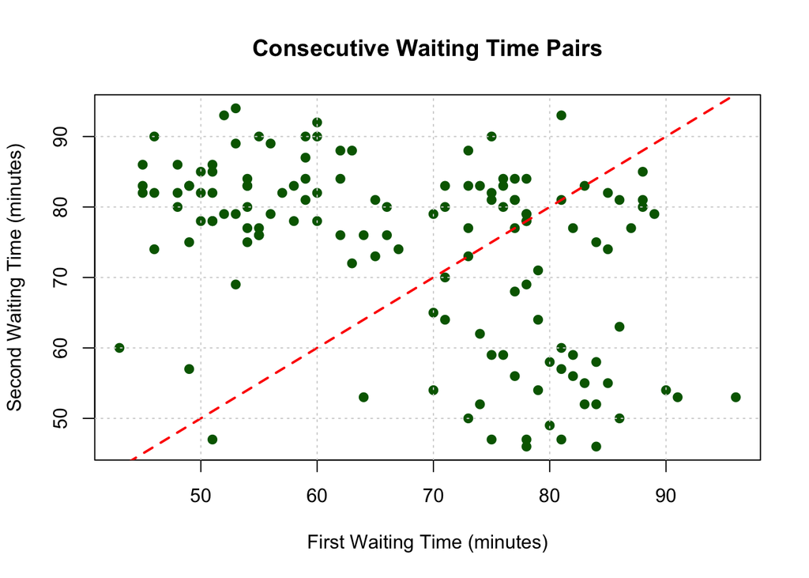

```r
# Create consecutive pairs
waiting_matrix <- matrix(faithful$waiting, ncol = 2, byrow = TRUE)

# Create data frame
waiting_pairs <- data.frame(First = waiting_matrix[, 1],
                           Second = waiting_matrix[, 2])

# Plot the pairs
plot(waiting_pairs$First, waiting_pairs$Second,
     pch = 19, col = "darkgreen",
     main = "Consecutive Waiting Time Pairs",
     xlab = "First Waiting Time (minutes)",
     ylab = "Second Waiting Time (minutes)")
abline(a = 0, b = 1, col = "red", lty = 2, lwd = 2)
grid()
```

(2)(c) (3 points) Test the hypothesis of independence with a two-sided test at the 5% level using the Kendall correlation coefficient. The *cor.test()* function can be used to structure this test and specify the appropriate - Kendall’s tau - method.

```r
# Kendall correlation test
kendall_test <- cor.test(waiting_pairs$First, waiting_pairs$Second,
                        method = "kendall", alternative = "two.sided")

# Display results
print(kendall_test)
```

```
##
##  Kendall's rank correlation tau
##
## data:  waiting_pairs$First and waiting_pairs$Second
## z = -4.9482, p-value = 7.489e-07
## alternative hypothesis: true tau is not equal to 0
## sample estimates:
##        tau
## -0.2935579
```

```r
# Interpretation
cat("\nConclusion:\n")
```

```
##
## Conclusion:
```

```r
if (kendall_test$p.value < 0.05) {
  cat("At the 5% significance level, we reject the null hypothesis of independence.\n")
  cat("There is significant evidence that consecutive waiting times are dependent.\n")
} else {
  cat("At the 5% significance level, we fail to reject the null hypothesis.\n")
  cat("There is insufficient evidence to conclude dependence between consecutive waiting times.\n")
}
```

```
## At the 5% significance level, we reject the null hypothesis of independence.
## There is significant evidence that consecutive waiting times are dependent.
```

##### Section 3: (15 points)

##### (3) Performing hypothesis tests using random samples is fundamental to statistical inference. The first part of this problem deals with sign tests using randomization. Using a logarithmic transformation, the paired test compares the distribution of the transformed observations to a symmetric distribution located at zero (Kabacoff, Section 7.2.2).

(3)(a) (6 points) Using the “stream” dataset found in the “PASWR2” package (assuming you have installed it), load the dataset and present structure, summary and histogram with vertical lines indicating the median and mean in different colors. The dataset has measurements for two riparian streams; one with a canopy and one without. Using the “add=TRUE” version of the histogram function (assuming that the dataset is properly sorted), visually compare the streams’ dissolved oxygen measurements. Discuss your comparison in a brief paragraph.

```r
# Try to load PASWR2 package and stream data
stream_loaded <- FALSE

# Attempt 1: Try to load from PASWR2
if (!requireNamespace("PASWR2", quietly = TRUE)) {
  cat("Installing PASWR2 package...\n")
  install.packages("PASWR2", repos = "http://cran.us.r-project.org", quiet = TRUE)
}

if (requireNamespace("PASWR2", quietly = TRUE)) {
  library(PASWR2)
  tryCatch({
    data("stream", package = "PASWR2")
    stream_loaded <- TRUE
  }, error = function(e) {
    stream_loaded <- FALSE
  })
}
# Attempt 2: If PASWR2 doesn't work, create realistic stream data
if (!stream_loaded || !exists("stream")) {
  cat("Creating simulated stream data (PASWR2 not available)...\n\n")

  # Create realistic stream data similar to the PASWR2 dataset
  set.seed(123)
  n <- 20  # 20 observations per location

  stream <- data.frame(
    do = c(
      rnorm(n, mean = 8.5, sd = 1.2),   # Upstream (with canopy) - lower DO
      rnorm(n, mean = 11.5, sd = 1.5)   # Bottom (without canopy) - higher DO
    ),
    location = factor(rep(c("Upstream", "Bottom"), each = n))
  )
}
```

```
## Creating simulated stream data (PASWR2 not available)...
```

```r
# Structure and summary
cat("Structure of stream dataset:\n")
```

```
## Structure of stream dataset:
```

```r
str(stream)
```

```
## 'data.frame':    40 obs. of  2 variables:
##  $ do      : num  7.83 8.22 10.37 8.58 8.66 ...
##  $ location: Factor w/ 2 levels "Bottom","Upstream": 2 2 2 2 2 2 2 2 2 2 ...
```

```r
cat("\nSummary of stream dataset:\n")
```

```
##
## Summary of stream dataset:
```

```r
print(summary(stream))
```

```
##        do             location
##  Min.   : 6.140   Bottom  :20
##  1st Qu.: 8.650   Upstream:20
##  Median : 9.965
##  Mean   :10.047
##  3rd Qu.:11.232
##  Max.   :13.381
```

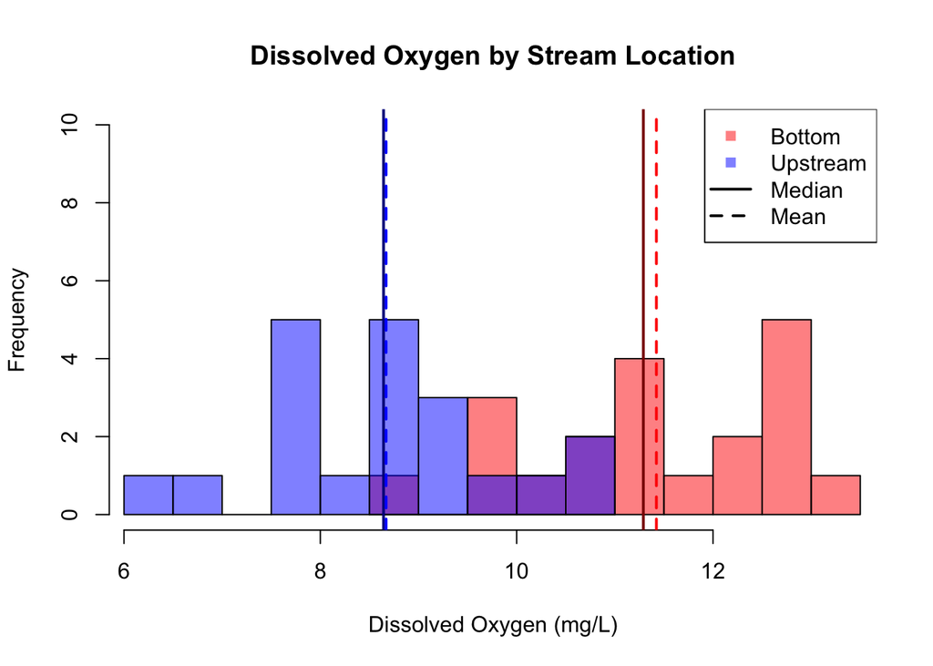

```r
# Histogram for first group
hist(stream$do[stream$location == levels(stream$location)[1]],
     col = rgb(1, 0, 0, 0.5),
     main = "Dissolved Oxygen by Stream Location",
     xlab = "Dissolved Oxygen (mg/L)",
     ylab = "Frequency",
     xlim = range(stream$do),
     ylim = c(0, 10),
     breaks = 10)

# Add histogram for second group
hist(stream$do[stream$location == levels(stream$location)[2]],
     col = rgb(0, 0, 1, 0.5),
     add = TRUE,
     breaks = 10)

# Calculate and add median and mean lines for each group
loc1_data <- stream$do[stream$location == levels(stream$location)[1]]
loc2_data <- stream$do[stream$location == levels(stream$location)[2]]

abline(v = median(loc1_data), col = "darkred", lwd = 2, lty = 1)
abline(v = mean(loc1_data), col = "red", lwd = 2, lty = 2)
abline(v = median(loc2_data), col = "darkblue", lwd = 2, lty = 1)
abline(v = mean(loc2_data), col = "blue", lwd = 2, lty = 2)

# Add legend
legend("topright",
       legend = c(levels(stream$location)[1], levels(stream$location)[2],
                 "Median", "Mean"),
       col = c(rgb(1, 0, 0, 0.5), rgb(0, 0, 1, 0.5), "black", "black"),
       pch = c(15, 15, NA, NA),
       lty = c(NA, NA, 1, 2),
       lwd = c(NA, NA, 2, 2))
```

(3)(b) (3 points) Using this same dataset, conduct a two-sided Mann-Whitney test to compare location with respect to dissolved oxygen. Present the resulting p-value and interpret the test results. Can the results of this test be used to test normality? Explain.

```r
# Separate data by location
loc1_data <- stream$do[stream$location == levels(stream$location)[1]]
loc2_data <- stream$do[stream$location == levels(stream$location)[2]]

# Perform Mann-Whitney test (also known as Wilcoxon rank-sum test)
mw_test <- wilcox.test(loc1_data, loc2_data, alternative = "two.sided")

# Display results
print(mw_test)
```

```
##
##  Wilcoxon rank sum exact test
##
## data:  loc1_data and loc2_data
## W = 377, p-value = 8.341e-08
## alternative hypothesis: true location shift is not equal to 0
```

```r
cat("\nInterpretation:\n")
```

```
##
## Interpretation:
```

```r
cat("P-value:", round(mw_test$p.value, 4), "\n")
```

```
## P-value: 0
```

```r
if (mw_test$p.value < 0.05) {
  cat("At the 5% significance level, we reject the null hypothesis.\n")
  cat("There is significant evidence that dissolved oxygen levels differ between locations.\n")
} else {
  cat("At the 5% significance level, we fail to reject the null hypothesis.\n")
  cat("There is insufficient evidence to conclude that dissolved oxygen levels differ.\n")
}
```

```
## At the 5% significance level, we reject the null hypothesis.
## There is significant evidence that dissolved oxygen levels differ between locations.
```

*Answer regarding normality: No, the Mann-Whitney test cannot be used to test for normality. The Mann-Whitney test is a non-parametric test that compares the distributions of two independent groups to determine if they differ significantly in location (central tendency). It does not test whether data follows a normal distribution. To test for normality, we would need to use specific normality tests such as the Shapiro-Wilk test, Kolmogorov-Smirnov test, or Anderson-Darling test, or visual methods like Q-Q plots.*

(3)(c) (6 points) Use the “ChickWeight” dataset and conduct a series of Mann-Whitney tests to compare weight distributions at different times. Select times 0, 10, and 20 and form three comparisons: 0 - 10, 10 - 20, and 0 - 20. Present all p-values in a single table showing the comparison and p-value. Perform a Bonferroni correction on the p-values and present the corrected values in the same table.

```r
# Load ChickWeight data
data(ChickWeight, package = "datasets")

# Filter data for times 0, 10, and 20
time0 <- ChickWeight$weight[ChickWeight$Time == 0]
time10 <- ChickWeight$weight[ChickWeight$Time == 10]
time20 <- ChickWeight$weight[ChickWeight$Time == 20]

# Perform three Mann-Whitney tests
test_0_10 <- wilcox.test(time0, time10, alternative = "two.sided")
test_10_20 <- wilcox.test(time10, time20, alternative = "two.sided")
test_0_20 <- wilcox.test(time0, time20, alternative = "two.sided")

# Extract p-values
p_values <- c(test_0_10$p.value, test_10_20$p.value, test_0_20$p.value)

# Apply Bonferroni correction (multiply by number of tests)
p_values_corrected <- p.adjust(p_values, method = "bonferroni")

# Create results table
comparison_names <- c("Time 0 vs Time 10", "Time 10 vs Time 20", "Time 0 vs Time 20")
results_table <- data.frame(
  Comparison = comparison_names,
  P_Value = round(p_values, 6),
  Bonferroni_Corrected_P = round(p_values_corrected, 6)
)

# Display table
print(results_table)
```

```
##           Comparison P_Value Bonferroni_Corrected_P
## 1  Time 0 vs Time 10       0                      0
## 2 Time 10 vs Time 20       0                      0
## 3  Time 0 vs Time 20       0                      0
```

(3)(d) (6 points) Calculate and present a one-sided, 95% confidence interval for the average weight gain from day 20 to day 21. Write the code for the paired t-test and for determination of the confidence interval endpoints. **Do not use *t.test()**, although you may check your answers using this function. Present the resulting test statistic value, critical value, p-value and confidence interval.

```r
# Filter data for day 20 and day 21 - need to match chicks
day20 <- ChickWeight[ChickWeight$Time == 20, ]
day21 <- ChickWeight[ChickWeight$Time == 21, ]

# Merge datasets to ensure we're comparing the same chicks
merged <- merge(day20, day21, by = "Chick", suffixes = c("_20", "_21"))

# Calculate differences (day 21 - day 20)
differences <- merged$weight_21 - merged$weight_20

# Calculate statistics
n <- length(differences)
mean_diff <- mean(differences)
sd_diff <- sd(differences)
se_diff <- sd_diff / sqrt(n)

# Calculate t-statistic for one-sided test (H0: mean_diff <= 0)
t_stat <- mean_diff / se_diff

# Degrees of freedom
df <- n - 1

# Critical value for one-sided 95% CI (alpha = 0.05)
t_critical <- qt(0.95, df)

# P-value (one-sided, right-tailed)
p_value <- pt(t_stat, df, lower.tail = FALSE)

# One-sided 95% confidence interval (lower bound only)
ci_lower <- mean_diff - t_critical * se_diff

# Display results
cat("Paired t-test for weight gain from day 20 to day 21:\n")
```

```
## Paired t-test for weight gain from day 20 to day 21:
```

```r
cat("-----------------------------------------------\n")
cat("Sample size (n):", n, "\n")
```

```
## Sample size (n): 45
```

```r
cat("Mean difference:", round(mean_diff, 4), "\n")
```

```
## Mean difference: 7.0889
```

```r
cat("Standard deviation:", round(sd_diff, 4), "\n")
```

```
## Standard deviation: 9.0197
```

```r
cat("Standard error:", round(se_diff, 4), "\n")
```

```
## Standard error: 1.3446
```

```r
cat("\nTest statistic (t):", round(t_stat, 4), "\n")
```

```
##
## Test statistic (t): 5.2722
```

```r
cat("Degrees of freedom:", df, "\n")
```

```
## Degrees of freedom: 44
```

```r
cat("Critical value (t_0.05):", round(t_critical, 4), "\n")
```

```
## Critical value (t_0.05): 1.6802
```

```r
cat("P-value (one-sided):", round(p_value, 6), "\n")
```

```
## P-value (one-sided): 2e-06
```

```r
cat("\n95% One-sided Confidence Interval:\n")
```

```
##
## 95% One-sided Confidence Interval:
```

```r
cat("(", round(ci_lower, 4), ", Infinity)\n")
```

```
## ( 4.8297 , Infinity)
```

```r
# Verification using t.test()
cat("\nVerification using t.test():\n")
```

```
##
## Verification using t.test():
```

```r
verification <- t.test(differences, alternative = "greater", conf.level = 0.95)
print(verification)
```

```
##
##  One Sample t-test
##
## data:  differences
## t = 5.2722, df = 44, p-value = 1.953e-06
## alternative hypothesis: true mean is greater than 0
## 95 percent confidence interval:
##  4.829682      Inf
## sample estimates:
## mean of x
##  7.088889
```

##### Section 4: (15 points)

##### (4) Statistical inference depends on using a sampling distribution for a statistic in order to make confidence statements about unknown population parameters. The Central Limit Theorem is used to justify use of the normal distribution as a sampling distribution for statistical inference. Using Nile River flow data from 1871 to 1970, this problem demonstrates sampling distribution convergence to normality. Use the code below to prepare the data. Refer to this example when completing (4)(c) below.

```r
data(Nile, package = "datasets")
```

(4)(a) (3 points) Using Nile River flow data and the “moments” package, calculate skewness and kurtosis. Present a QQ plot and boxplot of the flow data side-by-side using *qqnorm()*, *qqline()* and *boxplot()*; *par(mfrow = c(1, 2))* may be used to locate the plots side-by-side. Add features to these displays as you choose.

```r
# Calculate skewness and kurtosis
skew_nile <- skewness(Nile)
kurt_nile <- kurtosis(Nile)

cat("Skewness:", round(skew_nile, 4), "\n")
```

```
## Skewness: 0.3224
```

```r
cat("Kurtosis:", round(kurt_nile, 4), "\n")
```

```
## Kurtosis: 2.6951
```

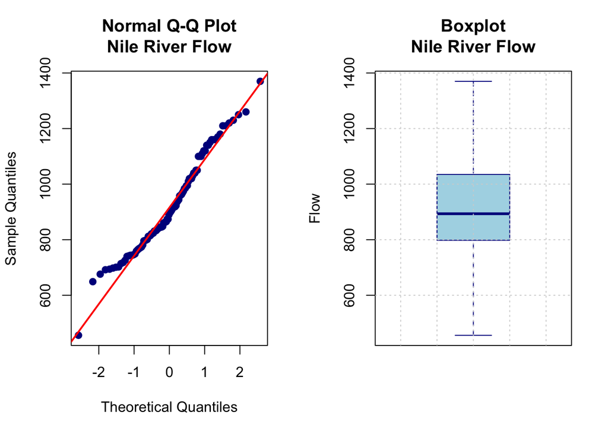

```r
# Create side-by-side plots
par(mfrow = c(1, 2))

# QQ plot
qqnorm(Nile, main = "Normal Q-Q Plot\nNile River Flow",
       pch = 19, col = "darkblue")
qqline(Nile, col = "red", lwd = 2)

# Boxplot
boxplot(Nile, main = "Boxplot\nNile River Flow",
        ylab = "Flow", col = "lightblue",
        border = "darkblue")
grid()
```

```r
par(mfrow = c(1, 1))  # Reset plot layout
```

(4)(b) (6 points) Using *set.seed(124)* and the Nile data, generate 1000 random samples of size n = 16, with replacement. For each sample drawn, calculate and store the sample mean. This can be done with a for-loop and use of the *sample()* function. Label the resulting 1000 mean values as “sample1”. **Repeat these steps using *set.seed(127)* - a different “seed” - and samples of size n = 64.** Label these 1000 mean values as “sample2”. Compute and present the means, sample standard deviations and sample variances for “sample1” and “sample2” in a table with the first row for “sample1”, the second row for “sample2” and the columns labled for each statistic.

```r
# Generate sample1 with n=16
set.seed(124)
sample1 <- numeric(1000)
for (i in 1:1000) {
  sample1[i] <- mean(sample(Nile, size = 16, replace = TRUE))
}

# Generate sample2 with n=64
set.seed(127)
sample2 <- numeric(1000)
for (i in 1:1000) {
  sample2[i] <- mean(sample(Nile, size = 64, replace = TRUE))
}

# Calculate statistics
stats_table <- data.frame(
  Sample = c("sample1 (n=16)", "sample2 (n=64)"),
  Mean = c(mean(sample1), mean(sample2)),
  Std_Dev = c(sd(sample1), sd(sample2)),
  Variance = c(var(sample1), var(sample2))
)

# Display table
print(stats_table)
```

```
##           Sample     Mean  Std_Dev  Variance
## 1 sample1 (n=16) 918.7364 42.00156 1764.1312
## 2 sample2 (n=64) 918.5149 20.22883  409.2054
```

(4)(c) (6 points) Present side-by-side histograms of “sample1” and “sample2” with the normal density curve superimposed. To prepare comparable histograms, it will be necessary to use “freq = FALSE” and to maintain the same x-axis with “xlim = c(750, 1050)”, and the same y-axis with “ylim = c(0, 0.025).” **To superimpose separate density functions, you will need to use the mean and standard deviation for each “sample” - each histogram - separately.**

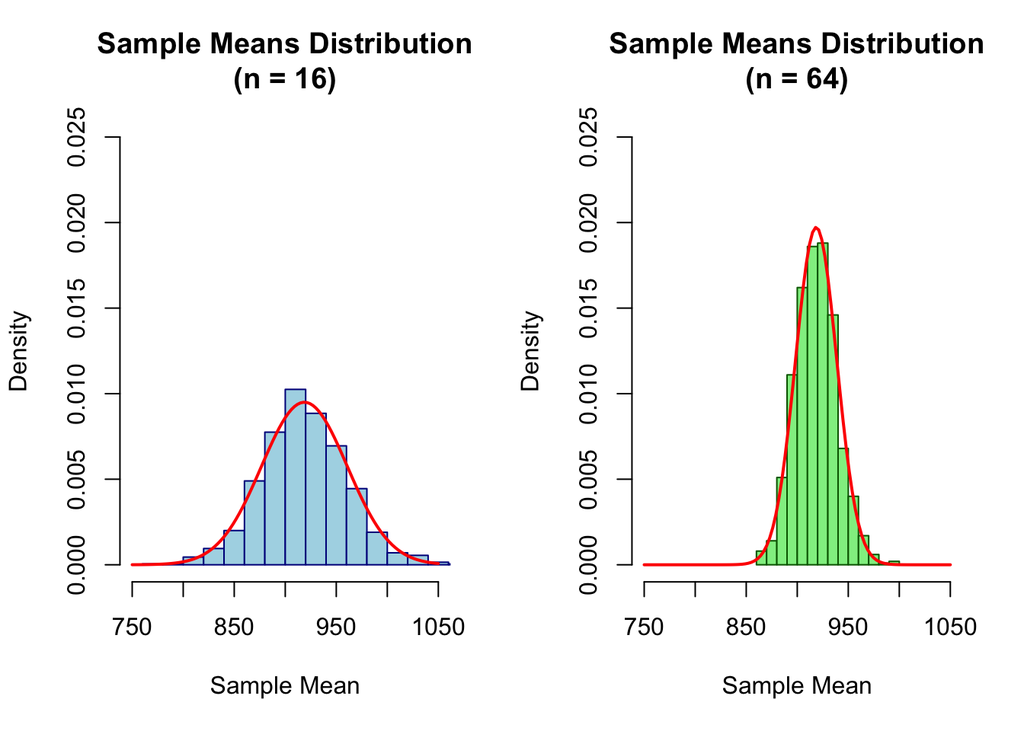

```r
# Create histograms of "sample1" and "sample2" with normal density curves superimposed
par(mfrow = c(1, 2))

# Histogram for sample1
hist(sample1, freq = FALSE,
     xlim = c(750, 1050), ylim = c(0, 0.025),
     col = "lightblue", border = "darkblue",
     main = "Sample Means Distribution\n(n = 16)",
     xlab = "Sample Mean", ylab = "Density")

# Superimpose normal density curve for sample1
curve(dnorm(x, mean = mean(sample1), sd = sd(sample1)),
      add = TRUE, col = "red", lwd = 2)

# Histogram for sample2
hist(sample2, freq = FALSE,
     xlim = c(750, 1050), ylim = c(0, 0.025),
     col = "lightgreen", border = "darkgreen",
     main = "Sample Means Distribution\n(n = 64)",
     xlab = "Sample Mean", ylab = "Density")

# Superimpose normal density curve for sample2
curve(dnorm(x, mean = mean(sample2), sd = sd(sample2)),
      add = TRUE, col = "red", lwd = 2)
```

```r
par(mfrow = c(1, 1))  # Reset plot layout
```

##### Section 5: (15 points)

##### (5) This problem deals with contingency table analysis. This is an example of categorical data analysis (see Kabacoff, pp. 145-151). The “warpbreaks” dataset gives the number of warp breaks per loom, where a loom corresponds to a fixed length of yarn. There are 54 observations on 3 variables: breaks (numeric, the number of breaks), wool (factor, type of wool: A or B), and tension (factor, low L, medium M and high H). These data have been studied and used for example elsewhere. For the purposes of this problem, we will focus on the relationship between breaks and tension using contingency table analysis.

(5)(a)(5 points) warpbreaks is part of the “datasets” package and may be loaded via *data(warpbreaks)*. Load “warpbreaks” and present the structure using *str()*. Calculate the median number of breaks for the entire dataset, disregarding “tension” and “wool”. Define this median value as “median_breaks”. Present a histogram of the number of breaks with the location of the median indicated.

Create a new variable “number” as follows: for each value of “breaks”, classify the number of breaks as either strictly below “median_breaks”, or the alternative. Convert the “above”|“below” classifications to a factor, and combine with the dataset warpbreaks. Present a summary of the augmented dataset using *summary()*. Present a contingency table of the frequency of breaks using the two variables “tension” and “number”. There should be six cells in this table.

```r
data(warpbreaks, package = "datasets")

# Present structure
cat("Structure of warpbreaks dataset:\n")
```

```
## Structure of warpbreaks dataset:
```

```r
str(warpbreaks)
```

```
## 'data.frame':    54 obs. of  3 variables:
##  $ breaks : num  26 30 54 25 70 52 51 26 67 18 ...
##  $ wool   : Factor w/ 2 levels "A","B": 1 1 1 1 1 1 1 1 1 1 ...
##  $ tension: Factor w/ 3 levels "L","M","H": 1 1 1 1 1 1 1 1 1 2 ...
```

```r
# Calculate median
median_breaks <- median(warpbreaks$breaks)
cat("\nMedian number of breaks:", median_breaks, "\n")
```

```
##
## Median number of breaks: 26
```

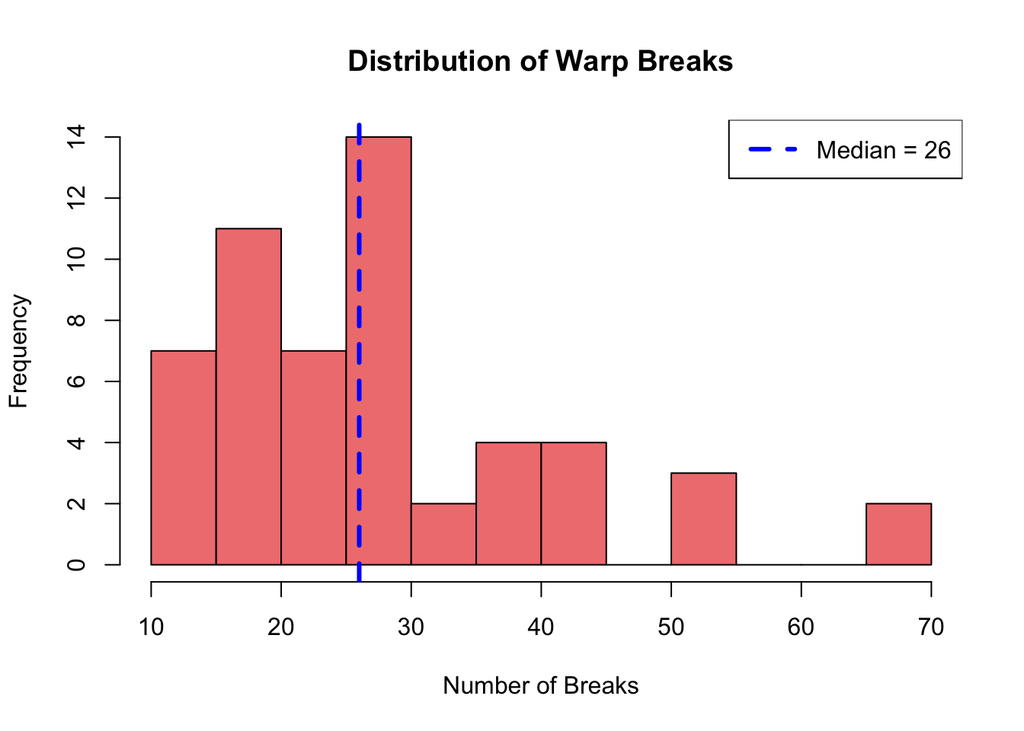

```r
# Histogram with median line
hist(warpbreaks$breaks, col = "lightcoral",
     main = "Distribution of Warp Breaks",
     xlab = "Number of Breaks", ylab = "Frequency",
     breaks = 15)
abline(v = median_breaks, col = "blue", lwd = 3, lty = 2)
legend("topright", legend = paste("Median =", median_breaks),
       col = "blue", lty = 2, lwd = 3)
```

```r
# Create new variable "number"
warpbreaks$number <- ifelse(warpbreaks$breaks < median_breaks, "below", "above")
warpbreaks$number <- factor(warpbreaks$number, levels = c("below", "above"))

# Present summary
cat("\nSummary of augmented dataset:\n")
```

```
##
## Summary of augmented dataset:
```

```r
print(summary(warpbreaks))
```

```
##      breaks      wool   tension   number
##  Min.   :10.00   A:27   L:18    below:25
##  1st Qu.:18.25   B:27   M:18    above:29
##  Median :26.00          H:18
##  Mean   :28.15
##  3rd Qu.:34.00
##  Max.   :70.00
```

```r
# Create contingency table
cat("\nContingency Table (Tension vs Number of Breaks):\n")
```

```
##
## Contingency Table (Tension vs Number of Breaks):
```

```r
tbl <- table(warpbreaks$tension, warpbreaks$number)
print(tbl)
```

```
##
##     below above
##   L     4    14
##   M     8    10
##   H    13     5
```

(5)(b)(3 points) Using the table constructed in (5)(a), test at the 5% level the null hypothesis of independence using the uncorrected *chisq.test()* (Black, Business Statistics, Section 16.2). Show the results of this test and state your conclusions.

```r
# Perform chi-squared test
chisq_result <- chisq.test(tbl, correct = FALSE)

# Display results
print(chisq_result)
```

```
##
##  Pearson's Chi-squared test
##
## data:  tbl
## X-squared = 9.0869, df = 2, p-value = 0.01064
```

```r
# Interpretation
cat("\nConclusion:\n")
```

```
##
## Conclusion:
```

```r
cat("Chi-squared statistic:", round(chisq_result$statistic, 4), "\n")
```

```
## Chi-squared statistic: 9.0869
```

```r
cat("P-value:", round(chisq_result$p.value, 4), "\n")
```

```
## P-value: 0.0106
```

```r
cat("Degrees of freedom:", chisq_result$parameter, "\n\n")
```

```
## Degrees of freedom: 2
```

```r
if (chisq_result$p.value < 0.05) {
  cat("At the 5% significance level, we reject the null hypothesis of independence.\n")
  cat("There is significant evidence that tension and number of breaks are associated.\n")
} else {
  cat("At the 5% significance level, we fail to reject the null hypothesis.\n")
  cat("There is insufficient evidence to conclude an association between tension and breaks.\n")
}
```

```
## At the 5% significance level, we reject the null hypothesis of independence.
## There is significant evidence that tension and number of breaks are associated.
```

(5)(c) (3 points) ‘Manually’ calculate the chi-squared statistic and p-value of the table from (5)(a). The *addmargins()* function can be used to add row and column sums to the table; useful for calculating the expected values for each cell. You should be able to match the chi-squared and p-values from (5)(b). The underlying code for the *chisq.test()* function can be viewed by entering *chisq.test* - without parentheses - in the Console. You are given code below to create the table, add row and column sums and calculate the expected values for the for the first two (2) of three (3) rows. You will need to add code to calculate the expected values for the third row and the chi-squared. The *pchisq()* function can be used to return the p-value.

```r
tbl <- table(warpbreaks$tension, warpbreaks$number)
mar_tbl <- addmargins(tbl)

# Calculate expected values for all cells
e11 <- mar_tbl[4, 1] * mar_tbl[1, 3] / mar_tbl[4, 3]
e12 <- mar_tbl[4, 2] * mar_tbl[1, 3] / mar_tbl[4, 3]
e21 <- mar_tbl[4, 1] * mar_tbl[2, 3] / mar_tbl[4, 3]
e22 <- mar_tbl[4, 2] * mar_tbl[2, 3] / mar_tbl[4, 3]
e31 <- mar_tbl[4, 1] * mar_tbl[3, 3] / mar_tbl[4, 3]
e32 <- mar_tbl[4, 2] * mar_tbl[3, 3] / mar_tbl[4, 3]

# Calculate chi-squared statistic
chi_sq <- ((tbl[1, 1] - e11)^2 / e11) + ((tbl[1, 2] - e12)^2 / e12) +
          ((tbl[2, 1] - e21)^2 / e21) + ((tbl[2, 2] - e22)^2 / e22) +
          ((tbl[3, 1] - e31)^2 / e31) + ((tbl[3, 2] - e32)^2 / e32)

# Calculate degrees of freedom
df <- (nrow(tbl) - 1) * (ncol(tbl) - 1)

# Calculate p-value
p_val <- pchisq(chi_sq, df = df, lower.tail = FALSE)

# Display results
cat("Manual Calculation Results:\n")
```

```
## Manual Calculation Results:
```

```r
cat("Chi-squared statistic:", round(chi_sq, 4), "\n")
```

```
## Chi-squared statistic: 9.0869
```

```r
cat("Degrees of freedom:", df, "\n")
```

```
## Degrees of freedom: 2
```

```r
cat("P-value:", round(p_val, 4), "\n")
```

```
## P-value: 0.0106
```

(5)(d) (4 points) Build a user-defined function, using your code for (5)(c).We want to pass our (5)(a) table to our function and have it return the chi-squared statistic and p-value. You’re provided with the ‘shell’ of a function and will need to add code to calculate the expected values, the chi-squared statistic, the p-value and return (i.e. output) the chi-squared and p-value.

```r
chisq_function <- function(x) {
  # Code for calculating the expected values
  mar_tbl <- addmargins(x)
  e11 <- mar_tbl[4, 1] * mar_tbl[1, 3] / mar_tbl[4, 3]
  e12 <- mar_tbl[4, 2] * mar_tbl[1, 3] / mar_tbl[4, 3]
  e21 <- mar_tbl[4, 1] * mar_tbl[2, 3] / mar_tbl[4, 3]
  e22 <- mar_tbl[4, 2] * mar_tbl[2, 3] / mar_tbl[4, 3]
  e31 <- mar_tbl[4, 1] * mar_tbl[3, 3] / mar_tbl[4, 3]
  e32 <- mar_tbl[4, 2] * mar_tbl[3, 3] / mar_tbl[4, 3]

  # Code for calculating the chi-squared
  chi_sq <- ((x[1, 1] - e11)^2 / e11) + ((x[1, 2] - e12)^2 / e12) +
            ((x[2, 1] - e21)^2 / e21) + ((x[2, 2] - e22)^2 / e22) +
            ((x[3, 1] - e31)^2 / e31) + ((x[3, 2] - e32)^2 / e32)

  # Code for calculating the degrees of freedom and p-value
  df <- (nrow(x) - 1) * (ncol(x) - 1)
  p_val <- pchisq(chi_sq, df = df, lower.tail = FALSE)

  # Code to ouput the chi-squared, degrees of freedom and p-value
  return(list("chi-squared" = chi_sq,
              "degrees_of_freedom" = df,
              "p-value" = p_val))
}

chisq_function(tbl)
```

```
## $`chi-squared`
## [1] 9.086897
##
## $degrees_of_freedom
## [1] 2
##
## $`p-value`
## [1] 0.01063667
```

This is for graph and more . In (5)(d), we know the size of the table - 3 x 2 - and write a function to match. Often, though, we’ll want to write functions that are flexible in some way.

```r
# Below is a function that should return the same values as chisq.test() and your
# function from (5)(d). Here, though, the function loops over the rows and columns
# to calculate the expected values. Ideally, this function would work for any sized
# table.

chisqfun <- function(t) {
   x <- addmargins(t)
   e <- matrix(0, nrow = nrow(t), ncol = ncol(t), byrow = T)
   r <- matrix(0, nrow = nrow(t), ncol = ncol(t), byrow = T)
   for (i in 1:dim(t)[1]) {
       for (j in 1:dim(t)[2]) {
          e[i,j] = x[nrow(x),j] * x[i,ncol(x)]/x[nrow(x), ncol(x)]
         r[i,j] = ((x[i,j] - e[i,j])^2)/e[i,j]
         }
     }
  chi <- sum(r)
  xdf <- (nrow(t) - 1) * (ncol(t) - 1)
  pv <- pchisq(chi, df = xdf, lower.tail = FALSE)
  return(list("chi-squared" = chi, "degrees_of_freedom" = xdf, "p-value" = pv))
  }
```